# Cálculos de pobreza monetaria en R. Con la Encuesta (tradicional) Nacional de Fuerza de Trabajo (ENFT)

Documento de uso privado. No difundir.

Por: Daniel E. de la Rosa

marzo 30, 2021

# 1 Librerías utilizadas

```r
library(dplyr)
```

```r
#library(enftr)
library(readxl)
library(haven)
library(tidyr)
library(stringr)
library(scales)
library(ggplot2)
```

# 2 Conexión a bases de datos

```r
enft_con <- Dmisc::dbConnect(db_name = "enft")
enft <- tbl(enft_con, "enft1") %>%
  filter(as.numeric(str_sub(EFT_PERIODO, 3)) <= 2006) %>%
  collect() %>%
  ft_compute_ano() %>%
  ft_compute_factor_onaplan()
enft_ie <- tbl(enft_con, "ingresos_exterior1")%>%
  collect()

enft_remesas <- tbl(enft_con, "remesas1") %>%
  collect()
```

```r
enft %>%
  group_by(EFT_PERIODO) %>%
  summarise(sum(factor_onaplan))
```

| EFT_PERIODO | sum(factor_onaplan) |
| --- | --- |
| 1/2000 | 8362429 |
| 1/2001 | 8498187 |
| 1/2002 | 8636149 |
| 1/2003 | 8776351 |
| 1/2004 | 8918829 |
| 1/2005 | 9063620 |
| 1/2006 | 9210761 |
| 2/2000 | 8430035 |
| 2/2001 | 8566891 |
| 2/2002 | 8705968 |

[output cut: 4 more lines]

# 3 Datos esperados

```r
ingresos <- read_excel("D:/MEGA/PARETO/DB/ENFTR/Pobreza Monetaria/Pages from td-13-medicion-de-la-pobreza-monetaria-en-rd.xlsx",
    skip = 1) %>%
  drop_na(ingreso) %>%
  pivot_longer(cols = -c("ingreso", "nombre"), names_to = "EFT_PERIODO", values_to = "esperado") %>%
  drop_na()
```

# 4 Cálculo de los ingresos

## 4.1 Ingreso 1. Ingreso monetario principal por ocupación principal

```r
enft %>%
  ft_compute_ing_ocup_prin_mensual() %>%
  group_by(EFT_PERIODO) %>%
  summarise(
    resultado = sum(ing_ocup_prin_mensual*factor_onaplan, na.rm = T)
  ) %>%
  left_join(
    ingresos[ingresos$ingreso == 1, c("EFT_PERIODO", "esperado")]
  ) %>%
  compare()
```

| EFT_PERIODO | resultado | esperado | diferencia | diferencia_relativa |
| --- | --- | --- | --- | --- |
| 1/2000 | 15926401477 | 15926401477 | 0.09040 | 0.0000000005676 |
| 1/2001 | 16265887204 | 16265887204 | 0.21398 | 0.0000000013155 |
| 1/2002 | 16780364337 | 16780364337 | -0.38422 | -0.0000000022897 |
| 1/2003 | 16755697080 | 16755697080 | -0.46754 | -0.0000000027904 |
| 1/2004 | 22201718806 | 22201718806 | -0.24001 | -0.0000000010810 |
| 1/2005 | 26110238807 | 26110238807 | 0.10591 | 0.0000000004056 |
| 1/2006 | 29339699356 | 29339699356 | -0.14053 | -0.0000000004790 |
| 2/2000 | 15469482485 | 15469482485 | 0.48069 | 0.0000000031073 |
| 2/2001 | 16148192115 | 16148192115 | 0.08158 | 0.0000000005052 |
| 2/2002 | 16790523395 | 16790523395 | 0.12181 | 0.0000000007255 |

[output cut: 4 more lines]

## 4.2 Ingreso 2. Ingreso monetario por ocupacion secundaria

```r
enft %>%
  ft_compute_ing_ocup_secun_mensual() %>%
  group_by(EFT_PERIODO) %>%
  summarise(
    resultado = sum(ing_ocup_secun_mensual*factor_onaplan, na.rm = T)
  ) %>%
  left_join(
    ingresos[ingresos$ingreso == 2, c("EFT_PERIODO", "esperado")]
  ) %>%
  compare()
```

| EFT_PERIODO | resultado | esperado | diferencia | diferencia_relativa |
| --- | --- | --- | --- | --- |
| 1/2000 | 863342948 | 863342948 | -0.21967 | -0.000000025444 |
| 1/2001 | 879954056 | 879954056 | 0.25951 | 0.000000029491 |
| 1/2002 | 1140148736 | 1140148736 | 0.28537 | 0.000000025029 |
| 1/2003 | 812345822 | 812345822 | 0.04711 | 0.000000005800 |
| 1/2004 | 1223911911 | 1223911911 | -0.08325 | -0.000000006802 |
| 1/2005 | 1104578780 | 1104578780 | -0.21927 | -0.000000019851 |
| 1/2006 | 1289701498 | 1289701498 | 0.22168 | 0.000000017189 |
| 2/2000 | 931222056 | 931222056 | -0.39521 | -0.000000042439 |
| 2/2001 | 992257689 | 992257689 | -0.11979 | -0.000000012072 |
| 2/2002 | 887851613 | 887851613 | 0.45235 | 0.000000050948 |

[output cut: 4 more lines]

Los ingresos están mensualizados de 2005 en adelante.

## 4.3 Ingreso 3. Ingreso monetario adicional comisiones laboral

```r
enft %>%
  ft_compute_ing_comisiones_mensual() %>%
  group_by(EFT_PERIODO) %>%
  summarise(
    resultado = sum(ing_comisiones_mensual*factor_onaplan, na.rm = T)
  ) %>%
  left_join(
    ingresos[ingresos$ingreso == 3, c("EFT_PERIODO", "esperado")]
  ) %>%
  compare()
```

| EFT_PERIODO | resultado | esperado | diferencia | diferencia_relativa |
| --- | --- | --- | --- | --- |
| 1/2000 | 0 | NA | NA | NA |
| 1/2001 | 0 | NA | NA | NA |
| 1/2002 | 0 | NA | NA | NA |
| 1/2003 | 0 | NA | NA | NA |
| 1/2004 | 0 | NA | NA | NA |
| 1/2005 | 398148061 | 398148061 | 0.4294 | 0.00000010786 |
| 1/2006 | 315980660 | 315980660 | 0.4748 | 0.00000015026 |
| 2/2000 | 0 | NA | NA | NA |
| 2/2001 | 0 | NA | NA | NA |
| 2/2002 | 0 | NA | NA | NA |

[output cut: 4 more lines]

## 4.4 Ingreso 4. Ingreso monetario adicional por propinas

```r
enft %>%
  ft_compute_ing_propinas_mensual() %>%
  group_by(EFT_PERIODO) %>%
  summarise(
    resultado = sum(ing_propinas_mensual*factor_onaplan, na.rm = T)
  ) %>%
  left_join(
    ingresos[ingresos$ingreso == 4, c("EFT_PERIODO", "esperado")]
  ) %>%
  compare()
```

| EFT_PERIODO | resultado | esperado | diferencia | diferencia_relativa |
| --- | --- | --- | --- | --- |
| 1/2000 | 0 | NA | NA | NA |
| 1/2001 | 0 | NA | NA | NA |
| 1/2002 | 0 | NA | NA | NA |
| 1/2003 | 0 | NA | NA | NA |
| 1/2004 | 0 | NA | NA | NA |
| 1/2005 | 137692161 | 137692161 | 0.38971 | 0.0000002830 |
| 1/2006 | 163214653 | 163214653 | 0.17861 | 0.0000001094 |
| 2/2000 | 0 | NA | NA | NA |
| 2/2001 | 0 | NA | NA | NA |
| 2/2002 | 0 | NA | NA | NA |

[output cut: 4 more lines]

## 4.5 Ingreso 5. Ingreso monetario adicional horas extras

```r
enft  %>%
  ft_compute_ing_horas_extras_mensual() %>%
  group_by(EFT_PERIODO) %>%
  summarise(
    resultado = sum(ing_horas_extras_mensual*factor_onaplan, na.rm = T)
  ) %>%
  left_join(
    ingresos[ingresos$ingreso == 5, c("EFT_PERIODO", "esperado")]
  ) %>%
  compare()
```

| EFT_PERIODO | resultado | esperado | diferencia | diferencia_relativa |
| --- | --- | --- | --- | --- |
| 1/2000 | 0 | NA | NA | NA |
| 1/2001 | 0 | NA | NA | NA |
| 1/2002 | 0 | NA | NA | NA |
| 1/2003 | 0 | NA | NA | NA |
| 1/2004 | 0 | NA | NA | NA |
| 1/2005 | 139542139 | 139542139 | 0.2069 | 0.0000001483 |
| 1/2006 | 127681540 | 127681540 | -0.4796 | -0.0000003756 |
| 2/2000 | 0 | NA | NA | NA |
| 2/2001 | 0 | NA | NA | NA |
| 2/2002 | 0 | NA | NA | NA |

[output cut: 4 more lines]

## 4.6 Ingreso 6. Ingreso monetario adicional por vacaciones

```r
enft  %>%
  ft_compute_ing_vacaciones_mensual() %>%
  group_by(EFT_PERIODO) %>%
  summarise(
    resultado = sum(ing_vacaciones_mensual*factor_onaplan, na.rm = T)
  ) %>%
  left_join(
    ingresos[ingresos$ingreso == 6, c("EFT_PERIODO", "esperado")]
  ) %>%
  compare()
```

| EFT_PERIODO | resultado | esperado | diferencia | diferencia_relativa |
| --- | --- | --- | --- | --- |
| 1/2000 | 0 | NA | NA | NA |
| 1/2001 | 0 | NA | NA | NA |
| 1/2002 | 0 | NA | NA | NA |
| 1/2003 | 0 | NA | NA | NA |
| 1/2004 | 0 | NA | NA | NA |
| 1/2005 | 185012613 | 185012613 | 0.01185 | 0.000000006403 |
| 1/2006 | 120915992 | 120915992 | -0.46257 | -0.000000382558 |
| 2/2000 | 0 | NA | NA | NA |
| 2/2001 | 0 | NA | NA | NA |
| 2/2002 | 0 | NA | NA | NA |

[output cut: 4 more lines]

## 4.7 Ingreso 7. Ingreso monetario adicional por dividendos

```r
enft  %>%
  ft_compute_ing_dividendos_mensual() %>%
  group_by(EFT_PERIODO) %>%
  summarise(
    resultado = sum(ing_dividendos_mensual*factor_onaplan, na.rm = T)
  ) %>%
  left_join(
    ingresos[ingresos$ingreso == 7, c("EFT_PERIODO", "esperado")]
  ) %>%
  compare()
```

| EFT_PERIODO | resultado | esperado | diferencia | diferencia_relativa |
| --- | --- | --- | --- | --- |
| 1/2000 | 0 | NA | NA | NA |
| 1/2001 | 0 | NA | NA | NA |
| 1/2002 | 0 | NA | NA | NA |
| 1/2003 | 0 | NA | NA | NA |
| 1/2004 | 0 | NA | NA | NA |
| 1/2005 | 41953752 | 41953752 | -0.33467 | -0.0000007977 |
| 1/2006 | 4885357 | 4885357 | -0.09597 | -0.0000019644 |
| 2/2000 | 0 | NA | NA | NA |
| 2/2001 | 0 | NA | NA | NA |
| 2/2002 | 0 | NA | NA | NA |

[output cut: 4 more lines]

## 4.8 Ingreso 8. Ingreso monetario adicional por bonificaciones

```r
enft  %>%
  ft_compute_ing_bonificaciones_mensual() %>%
  group_by(EFT_PERIODO) %>%
  summarise(
    resultado = sum(ing_bonificaciones_mensual*factor_onaplan, na.rm = T)
  ) %>%
  left_join(
    ingresos[ingresos$ingreso == 8, c("EFT_PERIODO", "esperado")]
  ) %>%
  compare()
```

| EFT_PERIODO | resultado | esperado | diferencia | diferencia_relativa |
| --- | --- | --- | --- | --- |
| 1/2000 | 0 | NA | NA | NA |
| 1/2001 | 0 | NA | NA | NA |
| 1/2002 | 0 | NA | NA | NA |
| 1/2003 | 0 | NA | NA | NA |
| 1/2004 | 0 | NA | NA | NA |
| 1/2005 | 164167725 | 164167725 | -0.21080 | -0.00000012840 |
| 1/2006 | 219705839 | 219705839 | 0.43101 | 0.00000019617 |
| 2/2000 | 0 | NA | NA | NA |
| 2/2001 | 0 | NA | NA | NA |
| 2/2002 | 0 | NA | NA | NA |

[output cut: 4 more lines]

## 4.9 Ingreso 9. Ingreso monetario adicional por regalia pascual

```r
enft  %>%
  ft_compute_ing_regalia_pascual_mensual() %>%
  group_by(EFT_PERIODO) %>%
  summarise(
    resultado = sum(ing_regalia_pascual_mensual*factor_onaplan, na.rm = T)
  ) %>%
  left_join(
    ingresos[ingresos$ingreso == 9, c("EFT_PERIODO", "esperado")]
  ) %>%
  compare()
```

| EFT_PERIODO | resultado | esperado | diferencia | diferencia_relativa |
| --- | --- | --- | --- | --- |
| 1/2000 | 0 | NA | NA | NA |
| 1/2001 | 0 | NA | NA | NA |
| 1/2002 | 0 | NA | NA | NA |
| 1/2003 | 0 | NA | NA | NA |
| 1/2004 | 0 | NA | NA | NA |
| 1/2005 | 744213585 | 744213585 | -0.44085 | -0.000000059237 |
| 1/2006 | 975427918 | 975427918 | 0.14728 | 0.000000015099 |
| 2/2000 | 0 | NA | NA | NA |
| 2/2001 | 0 | NA | NA | NA |
| 2/2002 | 0 | NA | NA | NA |

[output cut: 4 more lines]

## 4.10 Ingreso 10. Ingreso monetario adicional por utilidades empresariales

```r
enft  %>%
  ft_compute_ing_utilidades_empresariales_mensual() %>%
  group_by(EFT_PERIODO) %>%
  summarise(
    resultado = sum(ing_utilidades_empresariales_mensual*factor_onaplan, na.rm = T)
  ) %>%
  left_join(
    ingresos[ingresos$ingreso == 10, c("EFT_PERIODO", "esperado")]
  ) %>%
  compare()
```

| EFT_PERIODO | resultado | esperado | diferencia | diferencia_relativa |
| --- | --- | --- | --- | --- |
| 1/2000 | 0 | NA | NA | NA |
| 1/2001 | 0 | NA | NA | NA |
| 1/2002 | 0 | NA | NA | NA |
| 1/2003 | 0 | NA | NA | NA |
| 1/2004 | 0 | NA | NA | NA |
| 1/2005 | 142787125 | 142787125 | -0.3811 | -0.0000002669 |
| 1/2006 | 346907364 | 346907364 | 0.4700 | 0.0000001355 |
| 2/2000 | 0 | NA | NA | NA |
| 2/2001 | 0 | NA | NA | NA |
| 2/2002 | 0 | NA | NA | NA |

[output cut: 4 more lines]

## 4.11 Ingreso 11. Ingreso monetario adicional por beneficios marginales

```r
enft  %>%
  ft_compute_ing_beneficios_marginales_mensual() %>%
  group_by(EFT_PERIODO) %>%
  summarise(
    resultado = sum(ing_beneficios_marginales_mensual*factor_onaplan, na.rm = T)
  ) %>%
  left_join(
    ingresos[ingresos$ingreso == 11, c("EFT_PERIODO", "esperado")]
  ) %>%
  compare()
```

| EFT_PERIODO | resultado | esperado | diferencia | diferencia_relativa |
| --- | --- | --- | --- | --- |
| 1/2000 | 0 | NA | NA | NA |
| 1/2001 | 0 | NA | NA | NA |
| 1/2002 | 0 | NA | NA | NA |
| 1/2003 | 0 | NA | NA | NA |
| 1/2004 | 0 | NA | NA | NA |
| 1/2005 | 13563143 | 13563143 | -0.3984 | -0.0000029375 |
| 1/2006 | 30070868 | 30070868 | 0.2786 | 0.0000009266 |
| 2/2000 | 0 | NA | NA | NA |
| 2/2001 | 0 | NA | NA | NA |
| 2/2002 | 0 | NA | NA | NA |

[output cut: 4 more lines]

## 4.12 Ingreso 12. Ingreso laboral mensual en especie por alimentos

```r
enft  %>%
  ft_compute_ing_especie_alimentos_mensual() %>%
  group_by(EFT_PERIODO) %>%
  summarise(
    resultado = sum(ing_especie_alimentos_mensual*factor_onaplan, na.rm = T)
  ) %>%
  left_join(
    ingresos[ingresos$ingreso == 12, c("EFT_PERIODO", "esperado")]
  ) %>%
  compare()
```

| EFT_PERIODO | resultado | esperado | diferencia | diferencia_relativa |
| --- | --- | --- | --- | --- |
| 1/2000 | 0 | NA | NA | NA |
| 1/2001 | 0 | NA | NA | NA |
| 1/2002 | 0 | NA | NA | NA |
| 1/2003 | 0 | NA | NA | NA |
| 1/2004 | 0 | NA | NA | NA |
| 1/2005 | 359945476 | 359945476 | 0.3973 | 0.00000011036 |
| 1/2006 | 526354405 | 526354405 | -0.3168 | -0.00000006020 |
| 2/2000 | 0 | NA | NA | NA |
| 2/2001 | 0 | NA | NA | NA |
| 2/2002 | 0 | NA | NA | NA |

[output cut: 4 more lines]

## 4.13 Ingreso 13. Ingreso laboral mensual en especie por pago de vivienda

```r
enft %>%
  ft_compute_ing_especie_viviendas_mensual() %>%
  group_by(EFT_PERIODO) %>%
  summarise(
    resultado = sum(ing_especie_viviendas_mensual*factor_onaplan, na.rm = T)
  ) %>%
  left_join(
    ingresos[ingresos$ingreso == 13, c("EFT_PERIODO", "esperado")]
  ) %>%
  compare()
```

| EFT_PERIODO | resultado | esperado | diferencia | diferencia_relativa |
| --- | --- | --- | --- | --- |
| 1/2000 | 0 | NA | NA | NA |
| 1/2001 | 0 | NA | NA | NA |
| 1/2002 | 0 | NA | NA | NA |
| 1/2003 | 0 | NA | NA | NA |
| 1/2004 | 0 | NA | NA | NA |
| 1/2005 | 59292224 | 59292224 | 0.49995 | 0.00000084319 |
| 1/2006 | 81647352 | 81647352 | -0.04288 | -0.00000005252 |
| 2/2000 | 0 | NA | NA | NA |
| 2/2001 | 0 | NA | NA | NA |
| 2/2002 | 0 | NA | NA | NA |

[output cut: 4 more lines]

## 4.14 Ingreso 14. Ingreso laboral mensual en especie por pago de transporte

```r
enft %>%
  ft_compute_ing_especie_transporte() %>%
  group_by(EFT_PERIODO) %>%
  summarise(
    resultado = sum(ing_especie_transporte*factor_onaplan, na.rm = T)
  ) %>%
  left_join(
    ingresos[ingresos$ingreso == 14, c("EFT_PERIODO", "esperado")]
  ) %>%
  compare()
```

| EFT_PERIODO | resultado | esperado | diferencia | diferencia_relativa |
| --- | --- | --- | --- | --- |
| 1/2000 | 0 | NA | NA | NA |
| 1/2001 | 0 | NA | NA | NA |
| 1/2002 | 0 | NA | NA | NA |
| 1/2003 | 0 | NA | NA | NA |
| 1/2004 | 0 | NA | NA | NA |
| 1/2005 | 160086198 | 160086198 | 0.37371 | 0.00000023344 |
| 1/2006 | 225803809 | 225803809 | -0.21028 | -0.00000009313 |
| 2/2000 | 0 | NA | NA | NA |
| 2/2001 | 0 | NA | NA | NA |
| 2/2002 | 0 | NA | NA | NA |

[output cut: 4 more lines]

## 4.15 Ingreso 15. Ingreso laboral mensual en especie por vestido y calzado

```r
enft %>%
  ft_compute_ing_especie_vestido_mensual() %>%
  group_by(EFT_PERIODO) %>%
  summarise(
    resultado = sum(ing_especie_vestido_mensual*factor_onaplan, na.rm = T)
  ) %>%
  left_join(
    ingresos[ingresos$ingreso == 15, c("EFT_PERIODO", "esperado")]
  ) %>%
  compare()
```

| EFT_PERIODO | resultado | esperado | diferencia | diferencia_relativa |
| --- | --- | --- | --- | --- |
| 1/2000 | 0 | NA | NA | NA |
| 1/2001 | 0 | NA | NA | NA |
| 1/2002 | 0 | NA | NA | NA |
| 1/2003 | 0 | NA | NA | NA |
| 1/2004 | 0 | NA | NA | NA |
| 1/2005 | 23142069 | 23142069 | 0.01074 | 0.00000004641 |
| 1/2006 | 34123751 | 34123751 | -0.05891 | -0.00000017265 |
| 2/2000 | 0 | NA | NA | NA |
| 2/2001 | 0 | NA | NA | NA |
| 2/2002 | 0 | NA | NA | NA |

[output cut: 4 more lines]

## 4.16 Ingreso 16. Ingreso laboral mensual en especie por otros conceptos

```r
enft %>%
  ft_compute_ing_especie_otros_mensual() %>%
  group_by(EFT_PERIODO) %>%
  summarise(
    resultado = sum(ing_especie_otros_mensual*factor_onaplan, na.rm = T)
  ) %>%
  left_join(
    ingresos[ingresos$ingreso == 16, c("EFT_PERIODO", "esperado")]
  ) %>%
  compare()
```

| EFT_PERIODO | resultado | esperado | diferencia | diferencia_relativa |
| --- | --- | --- | --- | --- |
| 1/2000 | 0 | NA | NA | NA |
| 1/2001 | 0 | NA | NA | NA |
| 1/2002 | 0 | NA | NA | NA |
| 1/2003 | 0 | NA | NA | NA |
| 1/2004 | 0 | NA | NA | NA |
| 1/2005 | 22255549 | 22255549 | -0.25289 | -0.0000011363 |
| 1/2006 | 47062187 | 47062187 | 0.05429 | 0.0000001154 |
| 2/2000 | 0 | NA | NA | NA |
| 2/2001 | 0 | NA | NA | NA |
| 2/2002 | 0 | NA | NA | NA |

[output cut: 4 more lines]

## 4.17 Ingreso 17. Ingreso en especie no laboral por autoingreso o auntosuministro

```r
enft %>%
  ft_compute_ing_especie_auto() %>%
  group_by(EFT_PERIODO) %>%
  summarise(
    resultado = sum(ing_especie_auto*factor_onaplan, na.rm = T)
  ) %>%
  left_join(
    ingresos[ingresos$ingreso == 17, c("EFT_PERIODO", "esperado")]
  ) %>%
  compare()
```

| EFT_PERIODO | resultado | esperado | diferencia | diferencia_relativa |
| --- | --- | --- | --- | --- |
| 1/2000 | 0 | NA | NA | NA |
| 1/2001 | 0 | NA | NA | NA |
| 1/2002 | 0 | NA | NA | NA |
| 1/2003 | 0 | NA | NA | NA |
| 1/2004 | 0 | NA | NA | NA |
| 1/2005 | 585997581 | 602315001 | -16317420 | -2.70912 |
| 1/2006 | 756165883 | 756510306 | -344423 | -0.04553 |
| 2/2000 | 0 | NA | NA | NA |
| 2/2001 | 0 | NA | NA | NA |
| 2/2002 | 0 | NA | NA | NA |

[output cut: 4 more lines]

## 4.18 Ingreso 18. Ingreso imputado por uso de vivienda propia

```r
enft %>%
  ft_compute_ing_imputado_vivienda_propia() %>%
  group_by(EFT_PERIODO) %>%
  summarise(
    resultado = sum(ing_imputado_vivienda_propia*factor_onaplan, na.rm = T)
  ) %>%
  left_join(
    ingresos[ingresos$ingreso == 18, c("EFT_PERIODO", "esperado")]
  ) %>%
  compare()
```

| EFT_PERIODO | resultado | esperado | diferencia | diferencia_relativa |
| --- | --- | --- | --- | --- |
| 1/2000 | 2639705137 | 2639705137 | -0.121238 | -0.00000000459285 |
| 1/2001 | 2748624886 | 2748624886 | -0.104534 | -0.00000000380313 |
| 1/2002 | 2939669777 | 2939669777 | 0.366943 | 0.00000001248247 |
| 1/2003 | 2976143004 | 2976143004 | -0.003153 | -0.00000000010594 |
| 1/2004 | 3968998835 | 3968998835 | 0.002418 | 0.00000000006091 |
| 1/2005 | 3927313078 | 3927313078 | -0.053771 | -0.00000000136917 |
| 1/2006 | 4606930178 | 4606930178 | 0.180425 | 0.00000000391638 |
| 2/2000 | 2668424334 | 2668424334 | 0.253422 | 0.00000000949707 |
| 2/2001 | 2864647053 | 2864647053 | 0.332579 | 0.00000001160978 |
| 2/2002 | 2944796138 | 2944796138 | -0.113668 | -0.00000000385996 |

[output cut: 4 more lines]

## 4.19 Ingreso 19. Ingreso monetario no laboral por alquileres o rentas de propiedades

```r
enft %>%
  ft_compute_ing_alqui_renta_propiedades() %>%
  group_by(EFT_PERIODO) %>%
  summarise(
    resultado = sum(ing_alqui_renta_propiedades*factor_onaplan, na.rm = T)
  ) %>%
  left_join(
    ingresos[ingresos$ingreso == 19, c("EFT_PERIODO", "esperado")]
  ) %>%
  compare()
```

| EFT_PERIODO | resultado | esperado | diferencia | diferencia_relativa |
| --- | --- | --- | --- | --- |
| 1/2000 | 377511466 | 377511466 | 0.369175 | 0.000000097792 |
| 1/2001 | 394143600 | 394143600 | -0.202557 | -0.000000051392 |
| 1/2002 | 470848002 | 470848002 | -0.190205 | -0.000000040396 |
| 1/2003 | 314161874 | 314161874 | -0.293759 | -0.000000093506 |
| 1/2004 | 372105517 | 372105517 | 0.172811 | 0.000000046441 |
| 1/2005 | 466891574 | 466891574 | -0.343828 | -0.000000073642 |
| 1/2006 | 621920782 | 621920782 | 0.003402 | 0.000000000547 |
| 2/2000 | 287945738 | 287945738 | -0.384391 | -0.000000133494 |
| 2/2001 | 374771037 | 374771037 | 0.231984 | 0.000000061900 |
| 2/2002 | 360098827 | 360098827 | -0.257442 | -0.000000071492 |

[output cut: 4 more lines]

## 4.20 Ingreso 20. Ingreso monetario externo por intereses y alquiler

```r
enft %>%
  ft_compute_ing_ext_intereses_alquiler(enft_ie) %>%
  group_by(EFT_PERIODO) %>%
  summarise(
    resultado = sum(ing_ext_intereses_alquiler*factor_onaplan, na.rm = T)
  ) %>%
  left_join(
    ingresos[ingresos$ingreso == 20, c("EFT_PERIODO", "esperado")]
  ) %>%
  compare()
```

| EFT_PERIODO | resultado | esperado | diferencia | diferencia_relativa |
| --- | --- | --- | --- | --- |
| 1/2000 | 17632651.5 | 17632652 | -0.45283 | -0.0000025682 |
| 1/2001 | 31284791.5 | 31284474 | 317.49876 | 0.0010148765 |
| 1/2002 | 17788818.6 | 17788819 | -0.39801 | -0.0000022374 |
| 1/2003 | 202991446.9 | 202986980 | 4466.92450 | 0.0022005966 |
| 1/2004 | 78872254.8 | 78872255 | -0.20514 | -0.0000002601 |
| 1/2005 | 226783653.7 | 226784440 | -786.28744 | -0.0003467114 |
| 1/2006 | 1648890.3 | 1648890 | 0.29828 | 0.0000180897 |
| 2/2000 | 47105855.8 | 47106055 | -199.24566 | -0.0004229725 |
| 2/2001 | 896882.7 | 896883 | -0.33280 | -0.0000371063 |
| 2/2002 | 16737508.9 | 16737509 | -0.08114 | -0.0000004848 |

[output cut: 4 more lines]

## 4.21 Ingreso 21. Ingreso monetario no laboral por intereses o dividendos

```r
enft %>%
  ft_compute_ing_intereses_dividendo() %>%
  group_by(EFT_PERIODO) %>%
  summarise(
    resultado = sum(ing_intereses_dividendo*factor_onaplan, na.rm = T)
  ) %>%
  left_join(
    ingresos[ingresos$ingreso == 21, c("EFT_PERIODO", "esperado")]
  ) %>%
  compare()
```

| EFT_PERIODO | resultado | esperado | diferencia | diferencia_relativa |
| --- | --- | --- | --- | --- |
| 1/2000 | 204066214 | 204066214 | -0.43461 | -0.000000212975 |
| 1/2001 | 259192760 | 259192760 | 0.36027 | 0.000000138996 |
| 1/2002 | 184812442 | 184812442 | 0.35882 | 0.000000194154 |
| 1/2003 | 375148541 | 375148541 | -0.26114 | -0.000000069611 |
| 1/2004 | 316934330 | 316934330 | -0.01433 | -0.000000004523 |
| 1/2005 | 446137253 | 446137253 | -0.27693 | -0.000000062074 |
| 1/2006 | 728868789 | 728868789 | -0.21286 | -0.000000029205 |
| 2/2000 | 208252440 | 208252440 | 0.35548 | 0.000000170695 |
| 2/2001 | 109653933 | 109653933 | -0.21956 | -0.000000200228 |
| 2/2002 | 137783852 | 137783852 | -0.37668 | -0.000000273384 |

[output cut: 4 more lines]

## 4.22 Ingreso 22. Ingreso monetario no laboral por pensión o jubilación

```r
enft %>%
  ft_compute_ing_pension_jubilacion() %>%
  group_by(EFT_PERIODO) %>%
  summarise(
    resultado = sum(ing_pension_jubilacion*factor_onaplan, na.rm = T)
  ) %>%
  left_join(
    ingresos[ingresos$ingreso == 22, c("EFT_PERIODO", "esperado")]
  ) %>%
  compare()
```

| EFT_PERIODO | resultado | esperado | diferencia | diferencia_relativa |
| --- | --- | --- | --- | --- |
| 1/2000 | 263281418 | 263281418 | -0.39909 | -0.000000151584 |
| 1/2001 | 306827321 | 306827321 | 0.44639 | 0.000000145485 |
| 1/2002 | 416942152 | 416942152 | -0.01816 | -0.000000004355 |
| 1/2003 | 423777504 | 423777504 | 0.21431 | 0.000000050571 |
| 1/2004 | 532187650 | 532187650 | 0.04846 | 0.000000009105 |
| 1/2005 | 611431688 | 611431688 | 0.20595 | 0.000000033683 |
| 1/2006 | 705209462 | 705209462 | -0.13788 | -0.000000019552 |
| 2/2000 | 274522509 | 274522509 | -0.15318 | -0.000000055797 |
| 2/2001 | 346737526 | 346737526 | 0.12305 | 0.000000035488 |
| 2/2002 | 393390235 | 392040587 | 1349648.44366 | 0.344262428026 |

[output cut: 4 more lines]

## 4.23 Ingreso 23. Ingreso monetario no laboral externo por pensión.

```r
enft %>%
  ft_compute_ing_ext_pension(enft_ie) %>%
  group_by(EFT_PERIODO) %>%
  summarise(
    resultado = sum(ing_ext_pension*factor_onaplan, na.rm = T)
  ) %>%
  left_join(
    ingresos[ingresos$ingreso == 23, c("EFT_PERIODO", "esperado")]
  ) %>%
  compare()
```

| EFT_PERIODO | resultado | esperado | diferencia | diferencia_relativa |
| --- | --- | --- | --- | --- |
| 1/2000 | 179761008 | 179760945 | 62.5072 | 0.0000347724 |
| 1/2001 | 204906742 | 204906742 | -0.2664 | -0.0000001300 |
| 1/2002 | 257287008 | 257287008 | 0.4790 | 0.0000001862 |
| 1/2003 | 241747698 | 241743361 | 4336.9933 | 0.0017940486 |
| 1/2004 | 543950152 | 543950132 | 20.0567 | 0.0000036872 |
| 1/2005 | 215145564 | 215145924 | -360.0234 | -0.0001673392 |
| 1/2006 | 341818314 | 341818971 | -657.2089 | -0.0001922681 |
| 2/2000 | 274558890 | 274566706 | -7815.6066 | -0.0028465238 |
| 2/2001 | 204837034 | 204837034 | 0.2456 | 0.0000001199 |
| 2/2002 | 163884400 | 163884400 | -0.3623 | -0.0000002211 |

[output cut: 4 more lines]

## 4.24 Ingreso 24. Ingreso monetario no laboral por ayuda del gobierno

```r
enft %>%
  ft_compute_ing_ayuda_gobierno() %>%
  group_by(EFT_PERIODO) %>%
  summarise(
    resultado = sum(ing_ayuda_gobierno*factor_onaplan, na.rm = T)
  ) %>%
  left_join(
    ingresos[ingresos$ingreso == 24, c("EFT_PERIODO", "esperado")]
  ) %>%
  compare()
```

| EFT_PERIODO | resultado | esperado | diferencia | diferencia_relativa |
| --- | --- | --- | --- | --- |
| 1/2000 | 0 | NA | NA | NA |
| 1/2001 | 0 | NA | NA | NA |
| 1/2002 | 0 | NA | NA | NA |
| 1/2003 | 11302197 | 11302197 | -0.109410 | -0.000000968045 |
| 1/2004 | 14309876 | 14309876 | -0.430736 | -0.000003010060 |
| 1/2005 | 18465244 | 18465244 | -0.460986 | -0.000002496506 |
| 1/2006 | 100957337 | 100957337 | -0.006607 | -0.000000006544 |
| 2/2000 | 0 | NA | NA | NA |
| 2/2001 | 0 | NA | NA | NA |
| 2/2002 | 10441134 | 10441134 | -0.013792 | -0.000000132090 |

[output cut: 4 more lines]

## 4.25 Ingreso 25. Ingreso monetario no laboral por remesas nacionales

```r
enft %>%
  ft_compute_ing_remesas_nac() %>%
  group_by(EFT_PERIODO) %>%
  summarise(
    resultado = sum(ing_remesas_nac*factor_onaplan, na.rm = T)
  ) %>%
  left_join(
    ingresos[ingresos$ingreso == 25, c("EFT_PERIODO", "esperado")]
  ) %>%
  compare()
```

| EFT_PERIODO | resultado | esperado | diferencia | diferencia_relativa |
| --- | --- | --- | --- | --- |
| 1/2000 | 467334611 | 467334611 | 0.31052 | 0.000000066444 |
| 1/2001 | 592384568 | 592384568 | -0.45907 | -0.000000077496 |
| 1/2002 | 676893438 | 676893438 | 0.39091 | 0.000000057751 |
| 1/2003 | 778016903 | 778016903 | 0.41238 | 0.000000053004 |
| 1/2004 | 1138097253 | 1121594326 | 16502926.66656 | 1.471381076384 |
| 1/2005 | 1345974784 | 1345974784 | -0.36458 | -0.000000027086 |
| 1/2006 | 1610093992 | 1610093992 | 0.21002 | 0.000000013044 |
| 2/2000 | 556755424 | 556755424 | -0.18322 | -0.000000032909 |
| 2/2001 | 669567920 | 669567920 | -0.03577 | -0.000000005342 |
| 2/2002 | 740006668 | 740006668 | 0.28168 | 0.000000038065 |

[output cut: 4 more lines]

## 4.26 Ingreso 26. Ingreso monetario no laboral por remesas del exterior

- **Abril 2000**: de acuerdo con el citado documento, el cálculo del ingreso por remesas para este semestre se realiza tomando la variable disponible en el módulo de ingresos del exterior, y multiplicnado este por la frecuencia indicada, dividiendo el resultado entre 12. No obstante, en nuestra experiencia, el valor del indicador se encontraba semestralizado, por lo que la multiplicación por la frecuencia no fue necesaria, además de que la conversión a mensual requería una división por 6 en lugar de 12.

```r
enft %>%
  ft_compute_ing_remesas_ext(enft_remesas, enft_ie) %>%
  group_by(EFT_PERIODO) %>%
  summarise(
    resultado = sum(ing_remesas_ext*factor_onaplan, na.rm = T)
  ) %>%
  left_join(
    ingresos[ingresos$ingreso == 26, c("EFT_PERIODO", "esperado")]
  ) %>%
  compare()
```

| EFT_PERIODO | resultado | esperado | diferencia | diferencia_relativa |
| --- | --- | --- | --- | --- |
| 1/2000 | 1032768288 | 1009854733 | 22913555.02 | 2.268995161 |
| 1/2001 | 1137380140 | 1125796183 | 11583956.80 | 1.028956837 |
| 1/2002 | 966300914 | 950793571 | 15507342.87 | 1.630989454 |
| 1/2003 | 1142668363 | 1138147556 | 4520806.57 | 0.397207422 |
| 1/2004 | 2479725658 | 2479725625 | 32.95 | 0.000001329 |
| 1/2005 | 1736390500 | 1736389821 | 679.12 | 0.000039111 |
| 1/2006 | 2768869187 | 2771094861 | -2225674.20 | -0.080317503 |
| 2/2000 | 1199832909 | 1191405068 | 8427840.99 | 0.707386700 |
| 2/2001 | 1041994845 | 1028717354 | 13277490.83 | 1.290684052 |
| 2/2002 | 1048195449 | 1045802760 | 2392688.94 | 0.228789694 |

[output cut: 4 more lines]

## 4.27 Ingreso 27. Adicionales anuales no laborales por partidas registradas mensualmente

```r
enft %>%
  ft_compute_ing_adicionales() %>%
  group_by(EFT_PERIODO) %>%
  summarise(
    resultado = sum(ing_adicionales*factor_onaplan, na.rm = T)
  ) %>%
  left_join(
    ingresos[ingresos$ingreso == 27, c("EFT_PERIODO", "esperado")]
  ) %>%
  compare()
```

| EFT_PERIODO | resultado | esperado | diferencia | diferencia_relativa |
| --- | --- | --- | --- | --- |
| 1/2000 | 0 | NA | NA | NA |
| 1/2001 | 0 | NA | NA | NA |
| 1/2002 | 0 | NA | NA | NA |
| 1/2003 | 0 | NA | NA | NA |
| 1/2004 | 0 | NA | NA | NA |
| 1/2005 | 131222908 | 131222782 | 126.051 | 0.0000960589 |
| 1/2006 | 94026327 | 94020803 | 5523.788 | 0.0058750696 |
| 2/2000 | 0 | NA | NA | NA |
| 2/2001 | 0 | NA | NA | NA |
| 2/2002 | 0 | NA | NA | NA |

[output cut: 4 more lines]

## 4.28 Ingreso 28. Es el ingreso en especie no laboral por ayuda de familiares, no familiares e instituciones

```r
enft %>%
  ft_compute_ing_especie_ayuda_ong() %>%
  group_by(EFT_PERIODO) %>%
  summarise(
    resultado = sum(ing_especie_ayuda_ong*factor_onaplan, na.rm = T)
  ) %>%
  left_join(
    ingresos[ingresos$ingreso == 28, c("EFT_PERIODO", "esperado")]
  ) %>%
  compare()
```

| EFT_PERIODO | resultado | esperado | diferencia | diferencia_relativa |
| --- | --- | --- | --- | --- |
| 1/2000 | 0 | NA | NA | NA |
| 1/2001 | 0 | NA | NA | NA |
| 1/2002 | 0 | NA | NA | NA |
| 1/2003 | 0 | NA | NA | NA |
| 1/2004 | 0 | NA | NA | NA |
| 1/2005 | 842057294 | 842057294 | 0.15846 | 0.000000018818 |
| 1/2006 | 839261452 | 839261894 | -441.77223 | -0.000052638185 |
| 2/2000 | 0 | NA | NA | NA |
| 2/2001 | 0 | NA | NA | NA |
| 2/2002 | 0 | NA | NA | NA |

[output cut: 4 more lines]

## 4.29 Ingreso 29. Es el ingreso monetario no laboral por divorcio, herencia y otros ocasionales

```r
enft %>%
  ft_compute_ing_ocasional_nac() %>%
  group_by(EFT_PERIODO) %>%
  summarise(
    resultado = sum(ing_ocasional_nac*factor_onaplan, na.rm = T)
  ) %>%
  left_join(
    ingresos[ingresos$ingreso == 29, c("EFT_PERIODO", "esperado")]
  ) %>%
  compare()
```

| EFT_PERIODO | resultado | esperado | diferencia | diferencia_relativa |
| --- | --- | --- | --- | --- |
| 1/2000 | 0 | 161501141 | -161501141.0000 | -100.000000000000 |
| 1/2001 | 0 | 251431729 | -251431729.0000 | -100.000000000000 |
| 1/2002 | 0 | 150171698 | -150171698.0000 | -100.000000000000 |
| 1/2003 | 0 | 37082175 | -37082175.0000 | -100.000000000000 |
| 1/2004 | 0 | 72775651 | -72775651.0000 | -100.000000000000 |
| 1/2005 | 104911549 | 104911549 | 0.2123 | 0.000000202398 |
| 1/2006 | 451621871 | 451621871 | -0.1980 | -0.000000043837 |
| 2/2000 | 0 | 106002859 | -106002859.0000 | -100.000000000000 |
| 2/2001 | 0 | 66576617 | -66576617.0000 | -100.000000000000 |
| 2/2002 | 0 | 109840581 | -109840581.0000 | -100.000000000000 |

[output cut: 4 more lines]

## 4.30 Ingreso 30. Ingreso monetario externo por otros conceptos: herencia y similares

```r
enft %>%
  ft_compute_ing_ocasional_ext(enft_ie) %>%
  group_by(EFT_PERIODO) %>%
  summarise(
    resultado = sum(ing_ocasional_ext*factor_onaplan, na.rm = T)
  ) %>%
  left_join(
    ingresos[ingresos$ingreso == 30, c("EFT_PERIODO", "esperado")]
  ) %>%
  compare()
```

| EFT_PERIODO | resultado | esperado | diferencia | diferencia_relativa |
| --- | --- | --- | --- | --- |
| 1/2000 | 659714.6 | 659715 | -0.44003 | -0.0000667001 |
| 1/2001 | 28056308.1 | 28056308 | 0.06744 | 0.0000002404 |
| 1/2002 | 1821114.6 | 1821115 | -0.38678 | -0.0000212388 |
| 1/2003 | 3735604.3 | 3735529 | 75.34151 | 0.0020168899 |
| 1/2004 | 11530930.5 | 11530930 | 0.46503 | 0.0000040329 |
| 1/2005 | 41370989.1 | 41371011 | -21.89002 | -0.0000529115 |
| 1/2006 | 6370462.8 | 6370482 | -19.16223 | -0.0003007972 |
| 2/2000 | 29783370.0 | 29783464 | -93.95809 | -0.0003154706 |
| 2/2001 | 0.0 | 0 | 0.00000 | NaN |
| 2/2002 | 4506171.8 | 4506172 | -0.19557 | -0.0000043401 |

[output cut: 4 more lines]

## 4.31 Ingreso 31. Ingreso externo no monetario por regalos

```r
enft %>%
  ft_compute_ing_regalos_ext(enft_ie) %>%
  group_by(EFT_PERIODO) %>%
  summarise(
    resultado = sum(ing_regalos_ext*factor_onaplan, na.rm = T)
  ) %>%
  left_join(
    ingresos[ingresos$ingreso == 31, c("EFT_PERIODO", "esperado")]
  ) %>%
  compare()
```

| EFT_PERIODO | resultado | esperado | diferencia | diferencia_relativa |
| --- | --- | --- | --- | --- |
| 1/2000 | 352580964 | 352580964 | 0.2971 | 0.00000008426 |
| 1/2001 | 312167883 | 312073960 | 93923.4250 | 0.03009652743 |
| 1/2002 | 162126056 | 161743025 | 383030.6803 | 0.23681434193 |
| 1/2003 | 137745722 | 137745722 | -0.3492 | -0.00000025348 |
| 1/2004 | 124817706 | 124817706 | -0.4135 | -0.00000033130 |
| 1/2005 | 424226391 | 424226391 | 0.3197 | 0.00000007535 |
| 1/2006 | 637754626 | 637754626 | -0.4360 | -0.00000006836 |
| 2/2000 | 402653131 | 402653131 | -0.3979 | -0.00000009883 |
| 2/2001 | 192598515 | 187050126 | 5548388.5329 | 2.96625757571 |
| 2/2002 | 216510853 | 216510853 | 0.2772 | 0.00000012805 |

[output cut: 4 more lines]

## 4.32 Ingreso 32. Ingreso monetario no laboral por otros conceptos

```r
enft %>%
  ft_compute_ing_otros() %>%
  group_by(EFT_PERIODO) %>%
  summarise(
    resultado = sum(ing_otros*factor_onaplan, na.rm = T)
  ) %>%
  left_join(
    ingresos[ingresos$ingreso == 32, c("EFT_PERIODO", "esperado")]
  ) %>%
  compare()
```

| EFT_PERIODO | resultado | esperado | diferencia | diferencia_relativa |
| --- | --- | --- | --- | --- |
| 1/2000 | 161501141 | NA | NA | NA |
| 1/2001 | 251431729 | NA | NA | NA |
| 1/2002 | 150171698 | NA | NA | NA |
| 1/2003 | 37082175 | NA | NA | NA |
| 1/2004 | 73460988 | NA | NA | NA |
| 1/2005 | 131545995 | 131545995 | 0.1527 | 0.0000001161 |
| 1/2006 | 121131920 | 121131920 | 0.2419 | 0.0000001997 |
| 2/2000 | 106002859 | NA | NA | NA |
| 2/2001 | 66576617 | NA | NA | NA |
| 2/2002 | 109840581 | NA | NA | NA |

[output cut: 4 more lines]

## 4.33 Ingreso total

```r
enft %>%
  ft_compute_pobreza_monetaria(enft_ie, enft_remesas) %>%
  group_by(EFT_PERIODO) %>%
  summarise(
    resultado = sum(ing_pobreza_total*factor_onaplan, na.rm = T)
  ) %>%
  left_join(
    ingresos[ingresos$ingreso == 0, c("EFT_PERIODO", "esperado")]
  ) %>%
  compare()
```

| EFT_PERIODO | resultado | esperado | diferencia | diferencia_relativa |
| --- | --- | --- | --- | --- |
| 1/2000 | 22330156081 | 22463633421 | -133477340 | -0.5942 |
| 1/2001 | 23105414667 | 23400563791 | -295149124 | -1.2613 |
| 1/2002 | 23748232342 | 24149284120 | -401051778 | -1.6607 |
| 1/2003 | 23788786429 | 24208034248 | -419247819 | -1.7319 |
| 1/2004 | 32548434216 | 33063433550 | -514999334 | -1.5576 |
| 1/2005 | 40451053765 | 41078803236 | -627749471 | -1.5282 |
| 1/2006 | 47536622560 | 48244397713 | -707775153 | -1.4671 |
| 2/2000 | 22182019492 | 22448122269 | -266102777 | -1.1854 |
| 2/2001 | 22665993640 | 22993905287 | -327911647 | -1.4261 |
| 2/2002 | 23431176591 | 23820824489 | -389647898 | -1.6357 |

[output cut: 4 more lines]

## 4.34 Calculo de pobreza

```r
resultados_esperados <- read_excel("D:/MEGA/PARETO/DB/ENFTR/Pobreza Monetaria/Pages from td-13-medicion-de-la-pobreza-monetaria-en-rd-3 (Resultados).xlsx",
                                   skip = 6,
                                   col_names = F)[,c(1, 8:11)]
```

```
## * `` -> ...1
## * `` -> ...2
## * `` -> ...3
## * `` -> ...4
## * `` -> ...5
## * ...
```

```r
resultados_absolutos <- resultados_esperados[,c(1,2,4)] %>%
  drop_na() %>%
  setNames(c("EFT_PERIODO", 2, 1)) %>%
  pivot_longer(-EFT_PERIODO, names_to = "pobreza_monetaria", values_to = "morillo") %>%
  type.convert()

resultados_tasas <- resultados_esperados[,c(1,3,5)] %>%
  drop_na() %>%
  setNames(c("EFT_PERIODO", 2, 1)) %>%
  pivot_longer(-EFT_PERIODO, names_to = "pobreza_monetaria", values_to = "morillo")


pobreza_boletin <- read_excel("D:/MEGA/PARETO/DB/ENFTR/Pobreza Monetaria/Pages from boletín-de-estadísticas-oficiales-de-pobreza-monetaria-no-3.xlsx", skip = 3) %>%
  pivot_longer(-...1) %>%
  setNames(c("EFT_PERIODO", "pobreza_monetaria", "boletin")) %>%
  type.convert()
```

```
## * `` -> ...1
```

```r
res <- enft %>%
  ft_compute_pobreza_monetaria(enft_ie, enft_remesas) %>%
  group_by(
    EFT_PERIODO,
    pobreza_monetaria
  ) %>%
  summarise(
    resultado = sum(factor_onaplan)
  ) %>%
  dplyr::mutate(
    periodo = as.numeric(paste0(strsplit(EFT_PERIODO, "/")[[1]][[2]],strsplit(EFT_PERIODO, "/")[[1]][[1]]))
  ) %>%
  dplyr::arrange(periodo) %>%
  left_join(
  resultados_absolutos
) %>% left_join(
  pobreza_boletin
)
```

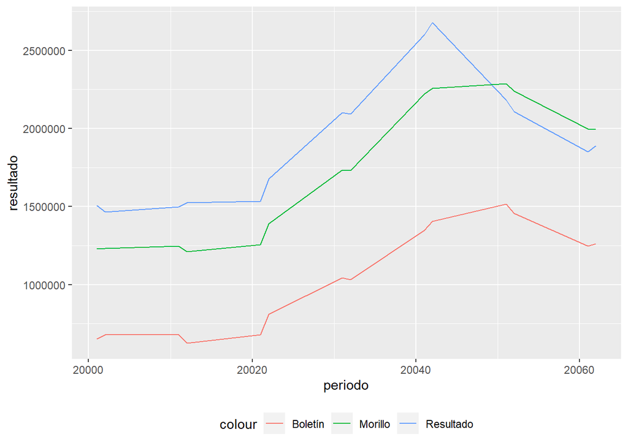

```r
res %>%
  dplyr::filter(pobreza_monetaria == 2) %>%
  ggplot()+
  geom_line(aes(periodo, resultado, color = "Resultado"))+
  theme(legend.position = "bottom") +
  geom_line(aes(periodo, morillo, color = "Morillo")) +
  geom_line(aes(periodo, boletin, color = "Boletín"))
```

# Bibliography

Allaire, JJ, Yihui Xie, Jonathan McPherson, Javier Luraschi, Kevin Ushey, Aron Atkins, Hadley Wickham, Joe Cheng, Winston Chang, and Richard Iannone. 2020. *Rmarkdown: Dynamic Documents for r*. https://github.com/rstudio/rmarkdown.

de la Rosa, Daniel E. 2020. “Rmdx: RMarkdown Extra Formats.” 'https://drdsdaniel.github.io/Rmdx/'.

R Core Team. 2020. *R: A Language and Environment for Statistical Computing*. Vienna, Austria: R Foundation for Statistical Computing. https://www.R-project.org/.

Copyleft © 2021 - Daniel E. de la Rosa w/ [Rmdx](https://drdsdaniel.github.io/Rmdx/)